# QTM 385 - Experimental Methods

Lecture 2 - The Research Design Process

Danilo Freire

danilo.freire@emory.edu

Emory University

# Hello, everyone! 👋 Nice to meet you again! 😊

# Recap and lecture overview 📚

## Brief recap

### About the course

- This is an applied course on experimental methods! 🤓
- All materials, including lectures, code, and assignments, are available online
  - Course website: https://danilofreire.github.io/qtm385/
  - GitHub repository: https://github.com/danilofreire/qtm385
- About me: Danilo Freire, VAP in QTM
  - Email: danilo.freire@emory.edu
  - Office hours: At your convenience, just send me an email first
- Teaching philosophy: Learning by doing, participation is always welcome, and I’m here to help you out! 😉

### Last week

- We saw a brief history of experimental methods and their main characteristics
  - Key milestones from Petrarch (1394) to modern RCTs, including James Lind’s scurvy experiment and the first psychological experiments by Pierce
- We also saw the main types of experiments
  - Lab experiments, field experiments, and natural experiments
  - We discussed the advantages and disadvantages of each type
- Finally, we briefly discussed the distinction between correlation and causation
- Key tools: R/Python, GitHub, Quarto, and Jupyter Notebooks
- Assignments: Problem sets (50%), pre-analysis plan (20%), and final project (30%), with a late policy and collaboration guidelines

## Course website and materials

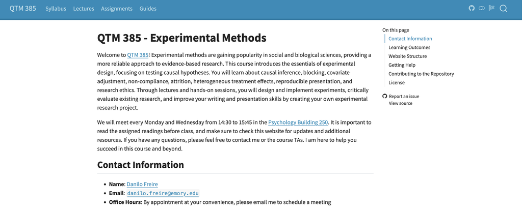

Click on the image to access the course website! 🌐

https://danilofreire.github.io/qtm385/

## Today’s lecture 📅

### The research design process: Questions and credibility

- What makes a research question good?
- The importance of theory (there’s no such thing as a theory-free observation!)
- Designing and selecting your treatment
- How to interpret your findings carefully
- The importance of transparency and reproducibility
- The research design process
- EGAP research design form

[Research Design](https://raw.githack.com/danilofreire/qtm385/main/lectures/lecture-02/02-design.html/)